# Segviz: A pacakge for the visualization of high throughput sequencing data along genomic segments.

Rene Welch and Sunduz Keles Department of Statistics, University of Wisconsin-Madison

# 1 Overview

This vignette provides an introduction to the visualization of sequencing data by using the *Segviz* package. The minimum input to the package includes:

1. Coordinates for regions of interest.
2. One or more bam files of aligned read data (e.g. from ChIP-seq experiments).

*Segviz* provides different tools to summarize and visualize these data, including but not limited to the following tasks:

- Extract read data of specified input regions.
- Plot data from different files (conditions) accross the same set of regions, e.g. peak plots for (SET or PET) ChIP-seq.
- Calculate and plot statistics(e.g. mean, median, variace, etc.) over a window around biologically meaningful coordinates (TSS, TFBS, etc.)
- Subset this regions according to user defined annotations.
- Plot the heatmap of signal curves accross regions separated by annotation.

# 2 How to use *Segviz*:

The package can be loaded with the command:

```r
  library(Segviz)
```

Different visualization of the data is done by the use of the **SegvizData** class. This class extends the *GenomicRanges* class to additionally contain **RleList**s with the experiment’s coverage.

## 2.1 Building a **SevisData** object

The minimum input for the package includes:

1. Coordinates for regions of interest.
2. One or more bam files of aligned read data (e.g. from ChIP-seq experiments).

The coordinates may be obtained by several means: Visual exploration in the genome browser, calling peaks from a ChIP-seq experiment, etc. To use *Segviz* it is necessary to load the regions of interest and the aligned reads (of one or several experiments) into a *SegvizData* object.

For example, if the peaks are saved in a **narrowPeak** file format (A description of several common file formats is given in https://genome.ucsc.edu/FAQ/FAQformat.html, then we can create the *SegvizData* object as follows:

```r
  dr = system.file("extdata","example",package = "Segvis")
  files = list.files(dr,pattern = "bam",full.names =TRUE)
  files = files[grep("bai",files,invert = TRUE)]

  peaks_file = file.path(dr,"encode_K562_Ctcf_peaks_first3chr.narrowPeak")
  ctcf = readBedFile(peaks_file)
  ctcf = reduce(ctcf) ## some peaks are listed more than one time
  frag_len = 200

  segviz = SegvizData(regions = ctcf,files,frag_len = frag_len)
  segviz
```

```
## SegvizData object with 152 ranges and 0 metadata columns:
##         seqnames                 ranges strand
##            <Rle>              <IRanges>  <Rle>
##     [1]     chr1   [18648915, 18649538]      *
##     [2]     chr1   [21985636, 21985951]      *
##     [3]     chr1   [24894180, 24894604]      *
##     [4]     chr1   [25286663, 25287087]      *
##     [5]     chr1   [26717999, 26718312]      *
##     ...      ...                    ...    ...
##   [148]     chr3 [183310007, 183310431]      *
##   [149]     chr3 [186868427, 186868851]      *
##   [150]     chr3 [195249031, 195249455]      *
##   [151]     chr3 [195616905, 195617329]      *
##   [152]     chr3 [196913824, 196914248]      *
##   -------
##   seqinfo: 3 sequences from an unspecified genome; no seqlengths
```

A complete description of the meaning of each column in the peaks file is given in https://genome.ucsc.edu/FAQ/FAQformat.html#format12.

## 2.2 Elements in a **SegvizData** object:

By using the *SegvizData* method, coverages are generated for each file of aligned reads, these profiles are accesible by using the *covers* method:

```r
  length(covers(segviz))
```

```
## [1] 5
```

```r
  covers(segviz)[[1]]
```

```
## RleList of length 3
## $chr1
## integer-Rle of length 249250621 with 10510 runs
##   Lengths: 18648645       12       24 ...      171       97  1638281
##   Values :        0        1        2 ...        2        1        0
##
## $chr2
## integer-Rle of length 243199373 with 7432 runs
##   Lengths: 6966240     116      22      31 ...      24     200 1050153
##   Values :       0       1       2       3 ...       0       1       0
##
## $chr3
## integer-Rle of length 198022430 with 7329 runs
##   Lengths: 1123473     194       4       2 ...     128       9 1107764
##   Values :       0       1       2       3 ...       2       1       0
```

Additionally for the case of DNA, coverage are generated by using only the reads that were aligned to certain strand.

```r
  fwd_covers(segviz)[[1]]
```

```
## RleList of length 3
## $chr1
## integer-Rle of length 249250621 with 6181 runs
##   Lengths: 18648760       88       85 ...       55        1  1638549
##   Values :        0        2        3 ...        2        1        0
##
## $chr2
## integer-Rle of length 243199373 with 4108 runs
##   Lengths: 6966240     183      17      25 ...      24     200 1050153
##   Values :       0       1       2       1 ...       0       1       0
##
## $chr3
## integer-Rle of length 198022430 with 4143 runs
##   Lengths: 1123473     198       2      23 ...     142       9 1107764
##   Values :       0       1       2       1 ...       2       1       0
```

```r
  bwd_covers(segviz)[[1]]
```

```
## RleList of length 3
## $chr1
## integer-Rle of length 249250621 with 6324 runs
##   Lengths: 18648645       12       24 ...      200       97  1638281
##   Values :        0        1        2 ...        2        1        0
##
## $chr2
## integer-Rle of length 243199373 with 4160 runs
##   Lengths: 6966356      22      31     106 ...      46       4 1050449
##   Values :       0       1       2       3 ...       2       1       0
##
## $chr3
## integer-Rle of length 198022430 with 3977 runs
##   Lengths: 1123667      15       1      18 ...      46      64 1107901
##   Values :       0       1       2       3 ...       3       1       0
```

Finally the number of aligned reads in each bam file is pre-processed and contained in the *SegvizData* object, it is accesible by:

```r
  nreads(segviz)
```

```
## [1] 22517 18303  7396  5107  6933
```

# 3 Visualization methods with *Segviz*:

## 3.1 How to plot one a region from the **SegvizData** object:

After creating a **SegvizData** object, one of the most simple capabilities to explore the data is to plot specific regions. For example, to plot a specific peak in the object is done by accesing its position in the **GRanges** object or just using a whole **GRanges** object:

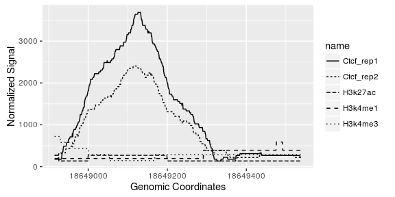

```r
  plot_region(segviz,1,nameFiles = c("Ctcf_rep1","Ctcf_rep2","H3k27ac",
                                     "H3k4me1","H3k4me3"))
```

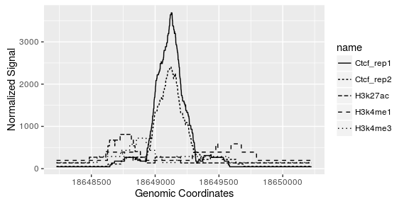

```r
  plot_region(segviz,resize(segviz[1],width = 2e3,fix = "center"),
              nameFiles = c("Ctcf_rep1","Ctcf_rep2","H3k27ac","H3k4me1","H3k4me3"))
```

Similarly to give more control to the user when plotting regions, we included the **DT_region** method which returns a data.table with the information used in the plot:

```r
    DT_region(segviz,1,nameFiles = c("Ctcf_rep1","Ctcf_rep2","H3k27ac",
                                     "H3k4me1","H3k4me3"))
```

```
##          coord     tags      name type
##    1: 18648915 177.6436 Ctcf_rep1 aggr
##    2: 18648916 177.6436 Ctcf_rep1 aggr
##    3: 18648917 177.6436 Ctcf_rep1 aggr
##    4: 18648918 177.6436 Ctcf_rep1 aggr
##    5: 18648919 177.6436 Ctcf_rep1 aggr
##   ---
## 3116: 18649534 288.4754   H3k4me3 aggr
## 3117: 18649535 288.4754   H3k4me3 aggr
## 3118: 18649536 288.4754   H3k4me3 aggr
## 3119: 18649537 288.4754   H3k4me3 aggr
## 3120: 18649538 288.4754   H3k4me3 aggr
```

## 3.2 How to plot the average profiles across all region in the **SegvizData** object:

To plot the average (o any other summary statistics) across a set of regions, the region need to have the same width. Therefore, a common method to normalize the width of the regions is to center them across the peaks summit:

```r
  bw = 500
  segviz$summit = find_summits(segviz,1)
  start(segviz) = segviz$summit - bw
  end(segviz) = segviz$summit + bw
  segviz
```

```
## SegvizData object with 152 ranges and 1 metadata column:
##         seqnames                 ranges strand |    summit
##            <Rle>              <IRanges>  <Rle> | <integer>
##     [1]     chr1   [18648627, 18649627]      * |  18649127
##     [2]     chr1   [21985279, 21986279]      * |  21985779
##     [3]     chr1   [24893834, 24894834]      * |  24894334
##     [4]     chr1   [25286350, 25287350]      * |  25286850
##     [5]     chr1   [26717666, 26718666]      * |  26718166
##     ...      ...                    ...    ... .       ...
##   [148]     chr3 [183309702, 183310702]      * | 183310202
##   [149]     chr3 [186868090, 186869090]      * | 186868590
##   [150]     chr3 [195248752, 195249752]      * | 195249252
##   [151]     chr3 [195616625, 195617625]      * | 195617125
##   [152]     chr3 [196913549, 196914549]      * | 196914049
##   -------
##   seqinfo: 3 sequences from an unspecified genome; no seqlengths
```

By construction the width is the same for all the intervals. Therefore to plot the average (median) profile is only necessary to do as follows:

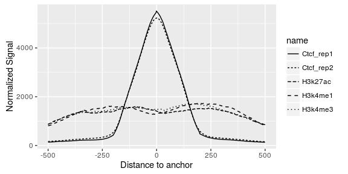

```r
  plot_profile(segviz,nameFiles = c("Ctcf_rep1","Ctcf_rep2","H3k27ac",
                                     "H3k4me1","H3k4me3"))
```

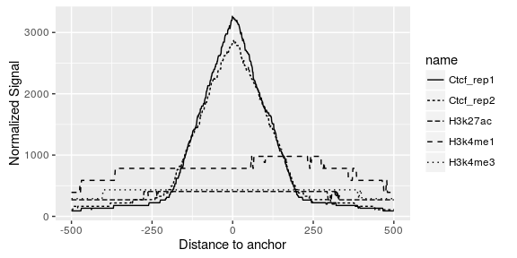

```r
  plot_profile(segviz,FUN = median,
               nameFiles = c("Ctcf_rep1","Ctcf_rep2","H3k27ac",
                                     "H3k4me1","H3k4me3"))
```

```r
  DT_profile(segviz,nameFiles = c("Ctcf_rep1","Ctcf_rep2","H3k27ac",
                                     "H3k4me1","H3k4me3"))
```

```
##       coord      name type     tags
##    1:  -500 Ctcf_rep1 aggr 134.6936
##    2:  -499 Ctcf_rep1 aggr 134.9857
##    3:  -498 Ctcf_rep1 aggr 135.5701
##    4:  -497 Ctcf_rep1 aggr 136.1544
##    5:  -496 Ctcf_rep1 aggr 137.0310
##   ---
## 5001:   496   H3k4me3 aggr 853.0901
## 5002:   497   H3k4me3 aggr 855.9369
## 5003:   498   H3k4me3 aggr 856.8858
## 5004:   499   H3k4me3 aggr 856.8858
## 5005:   500   H3k4me3 aggr 846.4476
```

## 3.3 How to plot a heatmap with the profiles across all region in the **SegvizData** object:

*Segviz* can plot heatmaps with the normalized signal profiles by using the plot_heatmap method:

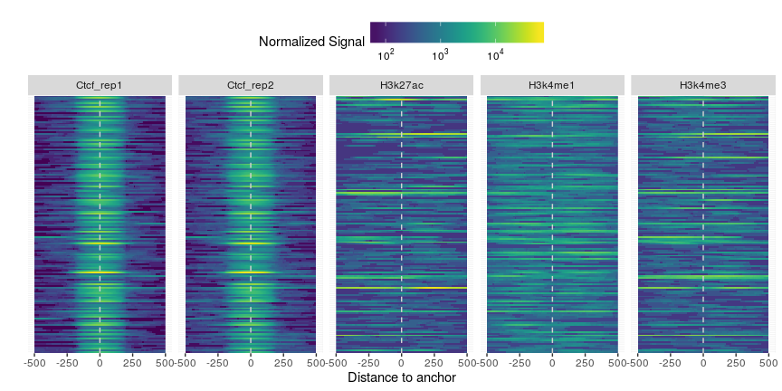

```r
  plot_heatmap(segviz,nameFiles = c("Ctcf_rep1","Ctcf_rep2","H3k27ac",
                                     "H3k4me1","H3k4me3"))
```

By default, the *plot_heatmap* method clusters the normalized signal across the windows by using the profiles from the first files added to the **SegvizData**, an eucliean distance and the complete agglomeration technique. However, by the use of the which.cluster, dist_method and clust_method parameters is possible to explore different clustering strategies when analizing the data.

# 4 A case of study: